# Homework 2

Jiajia Feng

2024-05-14

```r
library(tidyverse)
library(tidymodels)
```

```r
library(kknn)
library(ggplot2)
library(corrplot)
library(recipes)
library(yardstick)
library(broom)
abalone_data <- read_csv("data/abalone.csv")
codebook <- readLines("data/abalone_codebook.txt")
cat(codebook, sep="\n")
```

```
## Name / Data Type / Measurement Unit / Description
## -----------------------------
## Sex / nominal / -- / M, F, and I (infant)
## Length / continuous / mm / Longest shell measurement
## Diameter / continuous / mm / perpendicular to length
## Height / continuous / mm / with meat in shell
## Whole weight / continuous / grams / whole abalone
## Shucked weight / continuous / grams / weight of meat
## Viscera weight / continuous / grams / gut weight (after bleeding)
## Shell weight / continuous / grams / after being dried
## Rings / integer / -- / +1.5 gives the age in years
```

```r
names(abalone_data)
```

```
## [1] "type"           "longest_shell"  "diameter"       "height"
## [5] "whole_weight"   "shucked_weight" "viscera_weight" "shell_weight"
## [9] "rings"
```

# Question 1

```r
abalone_data <- abalone_data %>%
  mutate(age = rings + 1.5)
summary(abalone_data$age)
```

```
##    Min. 1st Qu.  Median    Mean 3rd Qu.    Max.
##    2.50    9.50   10.50   11.43   12.50   30.50
```

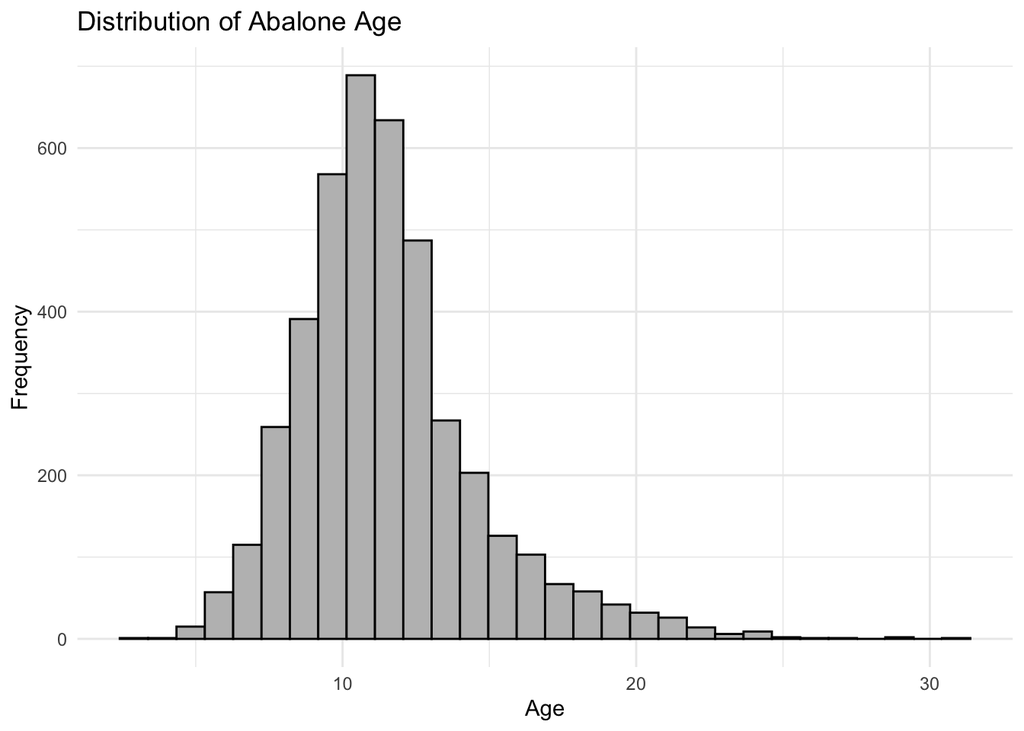

```r
ggplot(abalone_data, aes(x = age)) +
  geom_histogram(bins = 30, fill = "grey", color = "black") +
  theme_minimal() +
  labs(title = "Distribution of Abalone Age", x = "Age", y = "Frequency")
```

The histogram displays a right-skewed distribution. So while most abalone are of a younger age, there are fewer abalones that reach an older age, with the frequency steadily decreasing as age increases. The tallest bin appears to be around the age of 10. This suggests that the most common age among the abalones in this sample is around 10.5 years.

It’s clear that most abalones are relatively young, with a peak frequency around 10-11 years of age. There are fewer older abalones, with a significant drop in frequency past 15 years of age, and very few reach ages beyond 20 years.

# Question 2

```r
set.seed(123)

split <- initial_split(abalone_data, prop = 0.80, strata = age)
training_set <- training(split); training_set %>% head()
```

```
## # A tibble: 6 × 10
##   type  longest_shell diameter height whole_weight shucked_weight viscera_weight
##   <chr>         <dbl>    <dbl>  <dbl>        <dbl>          <dbl>          <dbl>
## 1 M             0.35     0.265  0.09         0.226         0.0995         0.0485
## 2 I             0.33     0.255  0.08         0.205         0.0895         0.0395
## 3 I             0.355    0.28   0.085        0.290         0.095          0.0395
## 4 M             0.365    0.295  0.08         0.256         0.097          0.043
## 5 M             0.465    0.355  0.105        0.480         0.227          0.124
## 6 F             0.45     0.355  0.105        0.522         0.237          0.116
## # ℹ 3 more variables: shell_weight <dbl>, rings <dbl>, age <dbl>
```

```r
testing_set <- testing(split); testing_set %>% head()
```

```
## # A tibble: 6 × 10
##   type  longest_shell diameter height whole_weight shucked_weight viscera_weight
##   <chr>         <dbl>    <dbl>  <dbl>        <dbl>          <dbl>          <dbl>
## 1 F             0.53      0.42  0.135        0.677          0.256         0.142
## 2 I             0.425     0.3   0.095        0.352          0.141         0.0775
## 3 M             0.475     0.37  0.125        0.509          0.216         0.112
## 4 M             0.49      0.38  0.135        0.542          0.218         0.095
## 5 M             0.45      0.32  0.1          0.381          0.170         0.075
## 6 F             0.615     0.48  0.165        1.16           0.513         0.301
## # ℹ 3 more variables: shell_weight <dbl>, rings <dbl>, age <dbl>
```

```r
summary(training_set$age)
```

```
##    Min. 1st Qu.  Median    Mean 3rd Qu.    Max.
##    2.50    9.50   10.50   11.44   12.50   30.50
```

```r
summary(testing_set$age)
```

```
##    Min. 1st Qu.  Median    Mean 3rd Qu.    Max.
##    4.50    9.50   10.50   11.42   12.50   25.50
```

# Question 3

```r
library(tidymodels)
names(abalone_data)
```

```
##  [1] "type"           "longest_shell"  "diameter"       "height"
##  [5] "whole_weight"   "shucked_weight" "viscera_weight" "shell_weight"
##  [9] "rings"          "age"
```

```r
abalone_recipe <- recipe(age ~ ., data=training_set) %>%
  step_rm(rings) %>%
  step_dummy(all_nominal_predictors()) %>%
  step_interact(terms = ~ starts_with("type"):shucked_weight)%>%
  step_interact(terms = ~ starts_with("longest_shell"):diameter)%>%
  step_interact(terms = ~ starts_with("shucked_weight"):shell_weight)%>%
  step_normalize(all_predictors())
```

Since `age` is computed using `rings`, the predictor (`rings`) and the outcome (`age`) are mathematically linked. This linkage leads to perfect predictability. Thus, there is no prediction challenge involved.

# Question 4

```r
linear_regression_model <- linear_reg() %>%
  set_engine("lm") %>%
  set_mode("regression")
```

# Question 5

```r
knn_model <- nearest_neighbor(neighbors = 7) %>%
  set_engine("kknn") %>%
  set_mode("regression")
```

# Question 6

```r
# Workflow for Linear Regression
workflow_linear <- workflow() %>%
  add_model(linear_regression_model) %>%
  add_recipe(abalone_recipe)

# Workflow for KNN
workflow_knn <- workflow() %>%
  add_model(knn_model) %>%
  add_recipe(abalone_recipe)

# Fit the Linear Regression Model to the training data
fit_linear <- fit(workflow_linear, data = training_set)

# Fit the KNN Model to the training data
fit_knn <- fit(workflow_knn, data = training_set)
```

# Question 7

```r
predict <- tibble(
  type = "F",
  longest_shell = 0.50,
  diameter = 0.10,
  height = 0.30,
  whole_weight = 4,
  shucked_weight = 1,
  viscera_weight = 2,
  shell_weight = 1,
  rings = 0  # As a placeholder, if required
)


abalone_predict <- predict(fit_linear, new_data = predict)
print(abalone_predict)
```

```
## # A tibble: 1 × 1
##   .pred
##   <dbl>
## 1  23.6
```

# Question 8

```r
library(yardstick)

metric <- metric_set(rsq, rmse, mae)
aba.lm.test <- augment(fit_linear, testing_set)
results_aba.lm.test <- metric(data=aba.lm.test, truth = age, estimate = .pred)
results_aba.lm.test
```

```
## # A tibble: 3 × 3
##   .metric .estimator .estimate
##   <chr>   <chr>          <dbl>
## 1 rsq     standard       0.548
## 2 rmse    standard       2.19
## 3 mae     standard       1.55
```

```r
aba.knn.test <- augment(fit_knn, testing_set)
results_aba.knn.test <- metric(data= aba.knn.test, truth = age, estimate = .pred)
results_aba.knn.test
```

```
## # A tibble: 3 × 3
##   .metric .estimator .estimate
##   <chr>   <chr>          <dbl>
## 1 rsq     standard       0.489
## 2 rmse    standard       2.33
## 3 mae     standard       1.66
```

# Question 9

The linear regression model performed better than the KNN model, because of a higher R-squared value. One reason for this could be that linear regression captures underlying relationships between variables more effectively, especially when these relationships are linear or nearly linear. In contrast, KNN relies on the proximity of similar data points.